# Southampton_PV_validation

Phil Wu: phil.wu@soton.ac.uk

17 October, 2018

1. randomly select a number of areas in Southampton
2. find out buildings in selected areas with pv - using satellite images
3. run model on these areas and see if these buildings were identified as suitable
4. discuss if conflict is found

[interactive chart not shown]

Then a number of cells are to be randomly selected, and eyeball check to find out buildings with pv on roof.

```
##  [1] "13"  "216" "651" "595" "232" "350" "589" "544" "252" "494"
```

[interactive chart not shown]

Identify buildings with PV

[interactive chart not shown]

Patrick’s comments: 1) 3 of 10 sample randomly selected areas are industrial and have no PV at the moment 2) This result does not help the validation, and so no need to mention them 3) It is better to target residential areas and gain greater sample size 4) Commercial buildings have larger roofs with higher PV potential, but their feasibility needs more rigorous assessment, so can be excluded from the scope of this work 5) New built houses have PV regardless of their feasibility, and they can also be eliminated from sample.

# Re-select sample areas from residential areas, and eyeball existing PV.

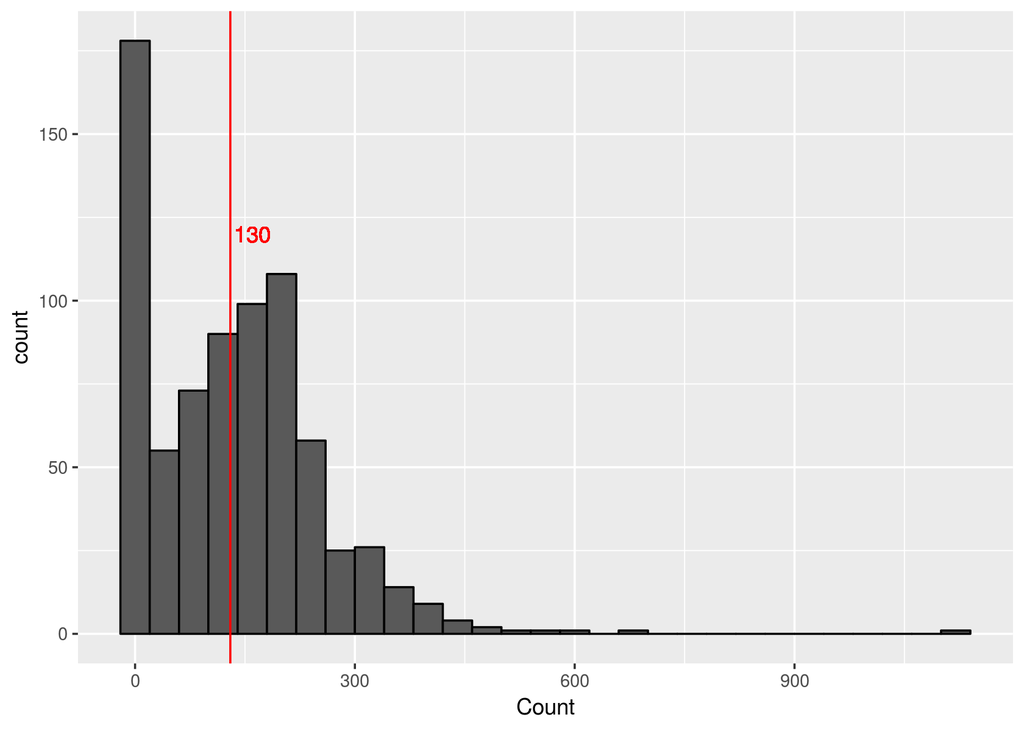

[interactive chart not shown]